# Modelos Mistos em Genética Quantitativa

Este material foi elaborado por alunos de pós-graduação do Programa de Genética e Melhoramento de Plantas da ESALQ. Faz parte de uma proposta de atividade da disciplina de Genética Quantitativa (LGE5810), ministrada pelo Prof. Dr. Antonio Augusto Franco Garcia.

Também foi realizado um vídeo contendo explicações sobre este tutorial. Acesse aqui.

Aqui explicaremos o uso de modelos mistos para predizer valores genéticos conforme diferentes conjuntos de dados. Simularemos diferentes situações para melhor entender os conceitos de genética quantitativa.

# Exemplo 1

Neste primeiro exemplo teremos indivíduos da seguinte genealogia de plantas de sorgo:

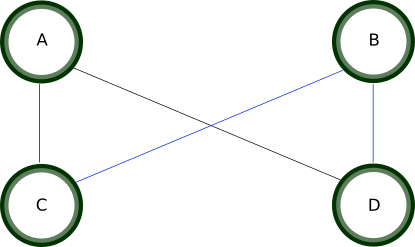

```r
library(kinship2)
pedigree <- data.frame(ind=c("A","B","C","D"),
                        P1=c( 0,  0, "A","A"),
                        P2=c( 0,  0, "B","B"))
```

```r
attach(pedigree)
cfam <- makefamid(ind, P1, P2)
kmat <- makekinship(cfam, ind, P1, P2)
(A <- as.matrix(2*kmat))
```

```
    A   B   C   D
A 1.0 0.0 0.5 0.5
B 0.0 1.0 0.5 0.5
C 0.5 0.5 1.0 0.5
D 0.5 0.5 0.5 1.0
```

Os valores fenotípicos são:

```r
set.seed(30)
fen <- rnorm(6, mean = 26, sd = 5)
(y <- matrix(fen, nrow=6))
```

```
         [,1]
[1,] 19.55741
[2,] 24.26155
[3,] 23.39186
[4,] 32.36737
[5,] 35.12260
[6,] 18.44346
```

A característica possui herdabilidade de 0,7.

```r
h2 <- 0.7 # heritability
```

A estimação e predição dos efeitos fixos e aleatórios é dada por:

$\left[ \begin{array} { l } { \hat { \beta } } \\ { \hat { u } } \end{array} \right] = \left[ \begin{array} { c c } { X ^ { \prime } X } & { X ^ { \prime } Z } \\ { Z ^ { \prime } X } & { Z ^ { \prime } Z + \lambda A ^ { - 1 } } \end{array} \right] ^ { - 1 } \left[ \begin{array} { l } { X ^ { \prime } y } \\ { Z ^ { \prime } y } \end{array} \right]$

$\hat{\bf{\theta}} = C^{-1}\bf{n}$

Definindo as matrizes X e Z:

```r
#Vetor com os fenótipos, matrizes X e Z:
X <- matrix(rep(1,6),nrow=6)
Z <- matrix(c(1,0,0,0,
              1,0,0,0,
              1,0,0,0,
              0,1,0,0,
              0,1,0,0,
              0,1,0,0),nrow=6,byrow=T)
```

Encontrando os produtos internos da matriz $C$:

```r
#Lambda
lamb <- (1-h2)/h2

#Matriz XX
(XX <- crossprod(X,X))
```

```
     [,1]
[1,]    6
```

```r
#Matriz XZ
(XZ <- t(X) %*% Z)
```

```
     [,1] [,2] [,3] [,4]
[1,]    3    3    0    0
```

```r
(ZX <- t(XZ))
```

```
     [,1]
[1,]    3
[2,]    3
[3,]    0
[4,]    0
```

```r
#Matriz ZZ + lambda*A
(ZZ <-crossprod(Z,Z) + lamb*solve(A))
```

```
           A          B          C          D
A  3.8571429  0.4285714 -0.4285714 -0.4285714
B  0.4285714  3.8571429 -0.4285714 -0.4285714
C -0.4285714 -0.4285714  0.8571429  0.0000000
D -0.4285714 -0.4285714  0.0000000  0.8571429
```

```r
#Matriz C
(C <- rbind(cbind(XX, XZ), cbind(ZX,ZZ)))
```

```
             A          B          C          D
  6  3.0000000  3.0000000  0.0000000  0.0000000
A 3  3.8571429  0.4285714 -0.4285714 -0.4285714
B 3  0.4285714  3.8571429 -0.4285714 -0.4285714
C 0 -0.4285714 -0.4285714  0.8571429  0.0000000
D 0 -0.4285714 -0.4285714  0.0000000  0.8571429
```

```r
#Vetor n
(n <- rbind(t(X)%*%y, t(Z)%*%y))
```

```
          [,1]
[1,] 153.14425
[2,]  67.21082
[3,]  85.93343
[4,]   0.00000
[5,]   0.00000
```

Para obter o BLUE e os BLUPs:

```r
(theta_hat <- solve(C)%*%n)
```

```
           [,1]
   2.552404e+01
A -2.730381e+00
B  2.730381e+00
C -1.421085e-14
D -1.421085e-14
```

```r
# Facilitando...

MM_solve <- function(fenVec, Xmat, Zmat, Amat, her){
  ## Lambda
  lamb <- (1-her)/her

  ## Matriz XX
  XX <- crossprod(Xmat,Xmat)

  ## Matriz XZ
  XZ <- t(Xmat) %*% Zmat
  ZX <- t(XZ)

  ## Matriz ZZ + lambda*A
  ZZ <-crossprod(Zmat) + lamb*solve(Amat)

  #Matriz C
  C <- rbind(cbind(XX, XZ), cbind(ZX,ZZ))

  #Vetor n
  n <- rbind(t(Xmat)%*%fenVec, t(Zmat)%*%fenVec)

  #Estimativa do BLUE e dos BLUPs
  theta_hat <- solve(C)%*%n

  return(theta_hat)
}
```

## Alterando os valores de herdabilidade

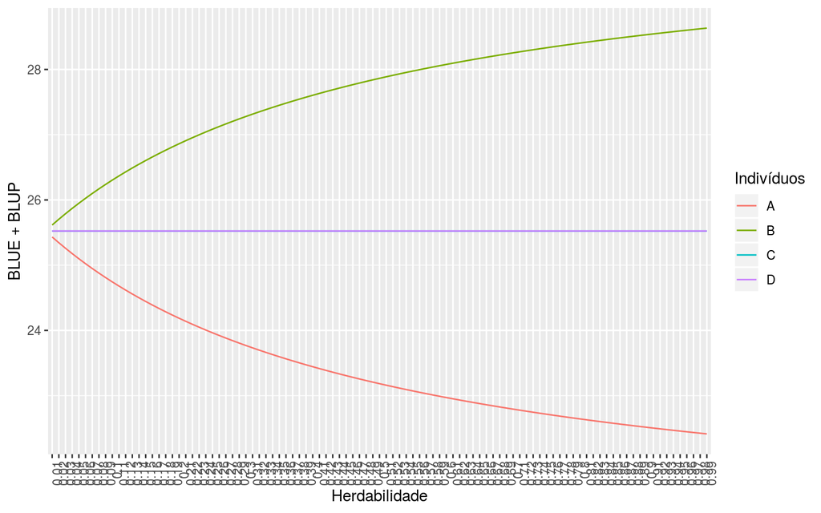

```r
herd <- seq(from = 0.01, to = 0.99, 0.01)

results <- data.frame(rep(NA, 5))
for(i in 1:length(herd))
  results[,i] <- MM_solve(y,X,Z,A,herd[i])

colnames(results) <- herd

for(i in 2:nrow(results))
  results[i,] <- results[i, ] + results[1,]

result_melt <- melt(t(results))
result_melt$Var1 <- as.factor(result_melt$Var1)
result_melt$Var2 <- factor(result_melt$Var2, labels = c("mu", "A", "B", "C", "D"))


ggplot(data=result_melt[which(result_melt$Var2 != "mu"),], aes(x= Var1, y=value, group = Var2, color=Var2)) +
  geom_line() + theme(axis.text.x = element_text(angle = 90, hjust = 1)) +
  xlab("Herdabilidade") + ylab("BLUE + BLUP") +
  guides(color = guide_legend(title = "Indivíduos"))
```

# Exemplo 2

Neste exemplo, utilizaremos a seguinte genealogia:

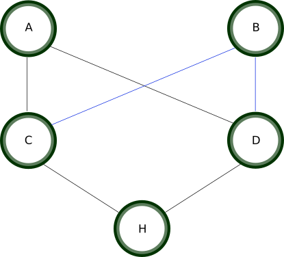

```r
# Pedrigree
(pedigree <- data.frame(ind=c("A","B","C", "D", "H"),
                        P1=c( 0,  0, "A", "A","C"),
                        P2=c( 0,  0, "B", "B","D")))
```

```
  ind P1 P2
1   A  0  0
2   B  0  0
3   C  A  B
4   D  A  B
5   H  C  D
```

```r
attach(pedigree)
cfam <- makefamid(ind, P1, P2)
kmat <- makekinship(cfam, ind, P1, P2)
detach(pedigree)

#Obtenção da matriz A
(A <- as.matrix(2*kmat))
```

```
    A   B    C    D    H
A 1.0 0.0 0.50 0.50 0.50
B 0.0 1.0 0.50 0.50 0.50
C 0.5 0.5 1.00 0.50 0.75
D 0.5 0.5 0.50 1.00 0.75
H 0.5 0.5 0.75 0.75 1.25
```

Os valores fenotípicos são:

```r
y <- c(15, 36, 40, 38, 32)
```

A característica possui herdabilidade de 0.6.

```r
h2 <- 0.6
```

Definindo as matrizes X e Z:

```r
#Vetor com os fenótipos, matrizes X e Z:
X <- matrix(c(1, 1, 1, 1,1), nrow = 5)
Z <- matrix(c(1,0,0,0,0,
              0,1,0,0,0,
              0,0,1,0,0,
              0,0,0,1,0,
              0,0,0,0,1), nrow = 5, byrow = TRUE)
```

```r
(theta_hat_e2 <- MM_solve(y, X, Z, A, h2))
```

```
       [,1]
  30.225275
A -6.300000
B  6.300000
C  3.972527
D  3.115385
H  2.785714
```

## Alterando o valor de herdabilidade

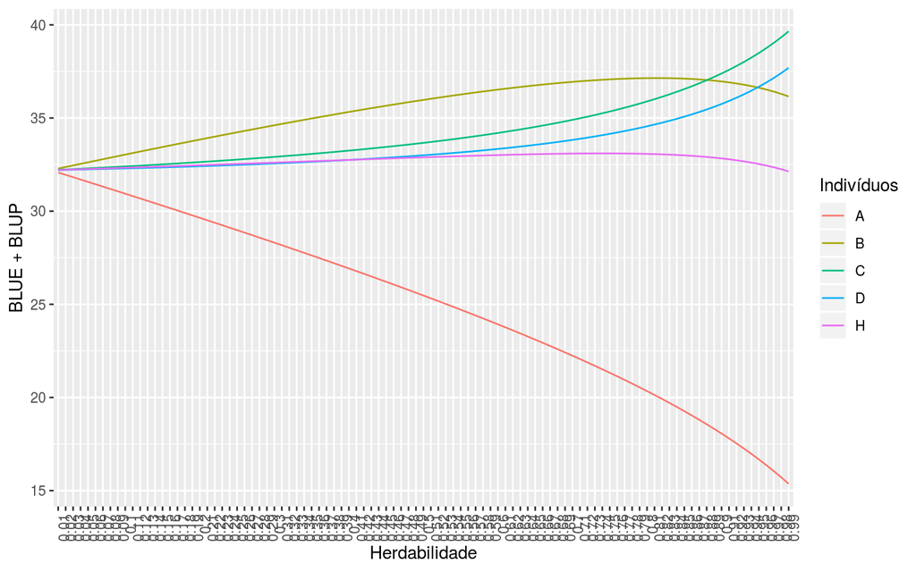

# Exemplo 3

Aqui, não teremos o valor fenotípico do indivíduo H. Todavia, conhecemos sua genealogia (a mesma do exemplo anterior). A herdabilidade continuará sendo de 0,6.

```r
# Vetor com os fenótipos, matrizes X e Z:
y <- c(15, 36, 40, 38)
X <- matrix(c(1, 1, 1, 1), nrow = 4)
Z <- matrix(c(1,0,0,0,0,
              0,1,0,0,0,
              0,0,1,0,0,
              0,0,0,1,0), nrow = 4, byrow = TRUE)


(theta_hat_e3 <- MM_solve(y, X, Z, A, h2))
```

```
       [,1]
  30.409091
A -6.300000
B  6.300000
C  4.110390
D  3.253247
H  3.681818
```

## Alterando o valor de herdabilidade

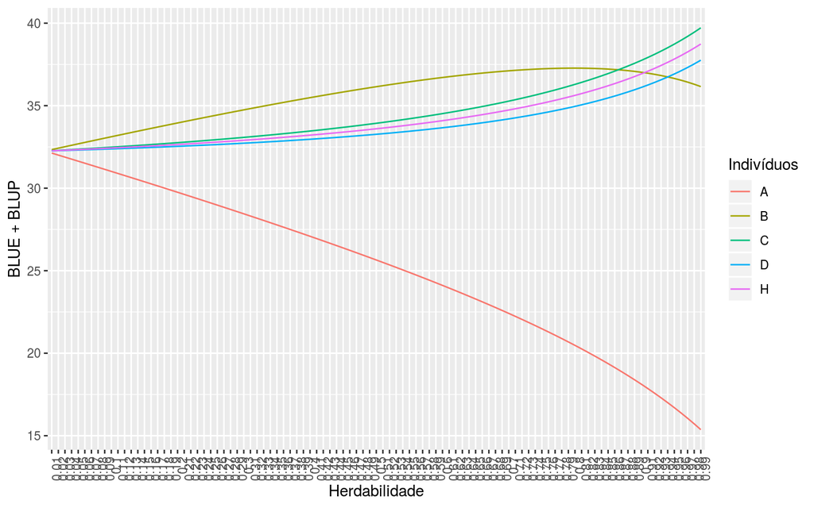

# Exemplo 4

Utilizaremos uma diferente genealogia de forma a alterarmos a matriz A. Veremos quais serão os valores estimados de $\theta$. A genealogia escolhida foi:

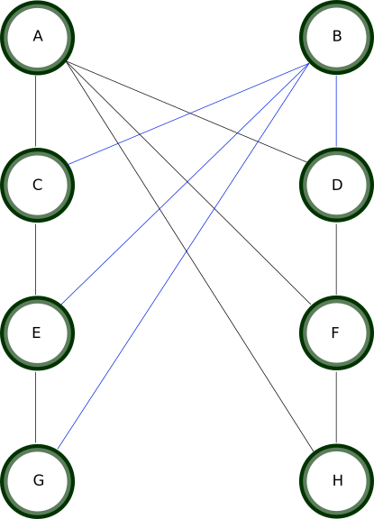

```r
# Pedrigree
(pedigree <- data.frame(ind=c("A","B","C", "D", "E","F","G","H"),
                        P1=c( 0,  0, "A", "A","B","A","B","A"),
                        P2=c( 0,  0, "B", "B","C","D","E","F")))
```

```
  ind P1 P2
1   A  0  0
2   B  0  0
3   C  A  B
4   D  A  B
5   E  B  C
6   F  A  D
7   G  B  E
8   H  A  F
```

```r
attach(pedigree)
cfam <- makefamid(ind, P1, P2)
kmat <- makekinship(cfam, ind, P1, P2)
detach(pedigree)

#Obtenção da matriz A
(A <- as.matrix(2*kmat))
```

```
      A     B     C     D      E      F       G       H
A 1.000 0.000 0.500 0.500 0.2500 0.7500 0.12500 0.87500
B 0.000 1.000 0.500 0.500 0.7500 0.2500 0.87500 0.12500
C 0.500 0.500 1.000 0.500 0.7500 0.5000 0.62500 0.50000
D 0.500 0.500 0.500 1.000 0.5000 0.7500 0.50000 0.62500
E 0.250 0.750 0.750 0.500 1.2500 0.3750 1.00000 0.31250
F 0.750 0.250 0.500 0.750 0.3750 1.2500 0.31250 1.00000
G 0.125 0.875 0.625 0.500 1.0000 0.3125 1.37500 0.21875
H 0.875 0.125 0.500 0.625 0.3125 1.0000 0.21875 1.37500
```

```r
#Herdabilidade
h2 <- 0.6

# Vetor com os fenótipos, matrizes X e Z:
y <- c(15, 36, 40, 38, 27, 32)
X <- matrix(c(1, 1, 1, 1, 1, 1), nrow = 6)
Z <- matrix(c(1,0,0,0,0,0,0,0,
              0,1,0,0,0,0,0,0,
              0,0,1,0,0,0,0,0,
              0,0,0,1,0,0,0,0,
              0,0,0,0,1,0,0,0,
              0,0,0,0,0,1,0,0), nrow = 6, byrow = TRUE)

theta_hat_e4 <- MM_solve(y, X, Z, A, h2)
```

## Alterando o valor de herdabilidade

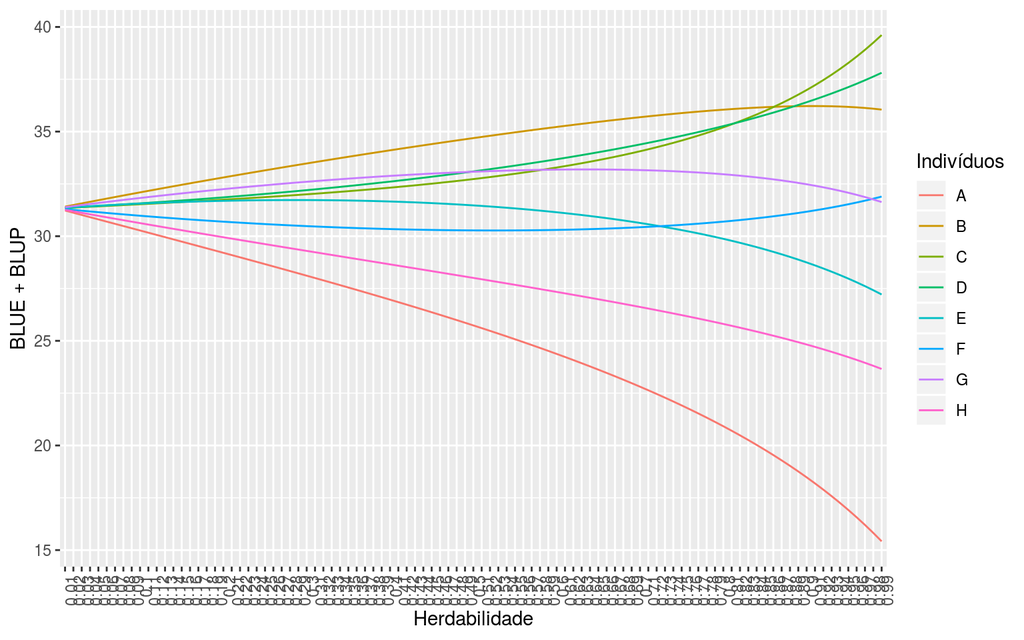

2018-11-26